# Kvantifikacija sličnosti i razlika složenih objekata

> U ovoj svesci ćemo uraditi frekvencijsku analizu slova u istom pisanom tekstu datom na trideset različitih jezika. Ovaj način parametrizacije će nam otvoriti mogućnost da definišemo metriku sličnosti jezika i da utvrdimo koji su jezici međusobno najsličniji. Na sličan način možemo da prametrizujemo i druge složene objekte.

Da bismo mogli da poredimo sličnosti ili razlike bilo kakvih objekata ili procesa moramo da ih kvantifikujemo. Moramo nešto što je kvalitativni opis da pretvorimo u kvantitativni. Da pojavu pretvorimo u niz brojčanih pokazatelja. Sliku možemo da predstavimo preko RGB komponenti boje za svaki piksel, muziku možemo da razložimo na spektar frekvencija, a performanse automobila da prikažemo preko indikatora snage, brzine, komfora itd.

Ovde ćemo probati da osmislimo meru sličnosti različitih jezika na osnovu učestanosti slova u pisanom tekstu. Za to nam je potreban tekst, još bolje isti tekst, na više različitih jezika. Za taj tekst ćemo onda uraditi frekvencijsku analizu. Tekst koji ćemo koristiti je vrlo kratka priča koja se baš tako zove -- "Vrlo kratka priča", Ernesta Hemingveja ([A Very Short Story](https://archive.org/details/AdvRAVeryShortStoryByErnestHemingway)). Ovaj smo već preveli na tridesetak jezika, ali ćemo videti kako možete sami da ih prevedete i na neke druge.

Za analizu teksta će nam biti potrebne neke retko korišćene biblioteke koje prvo treba instalirati. U sledećoj ćeliji je niz biblioteka koje treba instalirati. Da to ne bismo radili kad god pojkrenemo svesku, stavili smo komande kao komentare. Skinite *hash* znake `#` pre nego što izvršite komande u ovoj ćeliji.

```python
# pip install deep-translator
# pip install transliterate
# pip install unidecode
# pip install sparklines
```

U string **kratka** ćemo učitati originalni tekst veoma kratke priče (na engleskom) pomoću funkcije `read()`.

```python
fajl=open("data/kratka.txt", "r")
kratka = fajl.read()
```

Pošto priča nije previše duga, možemo da je prikažemo celu na ekranu.

```python
kratka
```

```
'One hot evening in Padua they carried him up onto the roof and he could look out over the top of the town. There were chimney swifts in the sky. After a while it got dark and the searchlights came out. The others went down and took the bottles with them. He and Luz could hear them below on the balc…
```

Pažljivo čitanje teksta će nam otkriti da u stringu **kratka** postoje kontrolni znaci "\n" koji označavaju prelom, ondnosno kraj linije teksta. To nam je samo smetnja za analizu pa ćemo te znake ukloniti. Tačnije, zamenićemo ih razmakom " " kako susedne reči u tekstu ne bi bile spojene.

```python
kratka_en=kratka.replace("\n"," ")
```

## Prevođenje

Da bismo tekst preveli na druge jezike, potrebna nam je biblioteka koja ima odgovarajuće funkcije. Ovde ćemo koristiti **GoogleTranslator**.

```python
from deep_translator import GoogleTranslator
```

Funkcije `GoogleTranslator()` ima dva parametra `source` i `target` kojima navodimo iz kog u koji jezik prevodimo tekst. Argument funkcije je sma string sa tekstom koji prevodimo. Ovde ćemo dati prevod vrlo kratke priče na srpski.

```python
prevod = GoogleTranslator(source='en', target='sr').translate(kratka_en)
```

```python
prevod
```

```
'Jedne vruće večeri u Padovi odneli su ga na krov i mogao je da gleda preko vrha grada. Na nebu su bile odžaci. Posle nekog vremena pao je mrak i ugasili su se reflektori. Ostali su sišli i poneli flaše sa sobom. On i Luz su mogli da ih čuju dole na balkonu. Luz je sedela na krevetu. Bila je hladna …
```

Ovo možda nije idealan prevod, ali će svakako poslužiti analizi koju planiramo. Lista svetskih jezika koji imaju svoj ISO kôd data je u fajlu **data/jezici.csv**. Google prevodilac nema mogućnost da prevede tekst baš na sve te jezike, ali radi za gotovo sve koji se koriste u Evropi. To će nam biti dovoljno za ovu vežbu. Kodove evropskih jezika ćemo izdvojiti u listu **lista**.

```python
import pandas as pd
```

```python
jezici=pd.read_csv('data/jezici.csv')
```

```python
jezici
```

|  | Language | ISO_Code |
| --- | --- | --- |
| 0 | Abkhazian | ab |
| 1 | Afar | aa |
| 2 | Afrikaans | af |
| 3 | Akan | ak |
| 4 | Albanian | sq |
| ... | ... | ... |
| 170 | Western Frisian | fy |
| 171 | Xhosa | xh |
| 172 | Yiddish | yi |
| 173 | Yoruba | yo |
| 174 | Zulu | zu |

175 rows × 2 columns

```python
lista=['bg','cs','da','de','el','en','es','et','hr','hu','fi','fr','is','it','lt','lv','mk','nl','no','pl','pt','ro','ru','sr',
       'sk','sl','sv','sq','tr','uk']
```

```python
len(lista)
```

```
30
```

Ovde možemo da prevodimo tekst **kratka** na sve željene jezike (što je vremenski zametno) ili da učitamo fajl u kom je tekst već preveden. Vi se odlučite za kraću ili dužu varijantu. Ako hoćete dužu, skinite *hash* sa početka narednih linija i izvršite ih. Ako hoćete kraću, idite odmah na učitavanje fajla **uzorak.csv**.

### Varijanta sa prevođenjem na sve jezike iz liste

Napravićemo *DataFrame* koji u prvim kolonama ima ISO kodove jezika na koje hoćemo da prevodimo. Tekst prevoda će za početak biti samo razmak `" "` (osim za vrstu gde je engleski original) koji ćemo posle zameniti tekstom prevoda.

```python
# uzorak=jezici[jezici.ISO_Code.isin(lista)]
```

```python
# uzorak=uzorak.assign(Text=" ")
```

```python
# uzorak.loc[uzorak['ISO_Code']=="en",'Text']=kratka_en
```

```python
# uzorak
```

```python
# for code in lista:
#    if code!="en":
#        prevod=GoogleTranslator(source='en', target=code).translate(kratka_en)
#        uzorak.loc[uzorak['ISO_Code']==code,'Text']=prevod
```

### Varijanta sa učitavanjem već prevedenih tekstova

```python
uzorak=pd.read_csv('data/uzorak.csv')
```

```python
uzorak
```

|  | Language | ISO_Code | Text |
| --- | --- | --- | --- |
| 0 | Albanian | sq | Një mbrëmje të nxehtë në Padova e çuan atë mbi... |
| 1 | Bulgarian | bg | Една гореща вечер в Падуа го изнесоха на покри... |
| 2 | Croatian | hr | Jedne vruće večeri u Padovi odnijeli su ga na ... |
| 3 | Czech | cs | Jednoho horkého večera v Padově ho vynesli na ... |
| 4 | Danish | da | En varm aften i Padua bar de ham op på taget, ... |
| 5 | Dutch | nl | Op een hete avond in Padua droegen ze hem het ... |
| 6 | English | en | One hot evening in Padua they carried him up o... |
| 7 | Estonian | et | Ühel kuumal õhtul Padovas viisid nad ta katuse... |
| 8 | Finnish | fi | Eräänä kuumana iltana Padovassa he veivät häne... |
| 9 | French | fr | Par une chaude soirée à Padoue, ils le portère... |
| 10 | German | de | An einem heißen Abend in Padua trugen sie ihn ... |
| 11 | Greek | el | Ένα καυτό βράδυ στην Πάντοβα τον ανέβασαν στην... |
| 12 | Hungarian | hu | Egy forró estén Padovában felvitték a tetőre, ... |
| 13 | Icelandic | is | Eitt heitt kvöld í Padua báru þeir hann upp á ... |
| 14 | Italian | it | Una calda sera di Padova lo portarono sul tett... |
| 15 | Latvian (Lettish) | lv | Kādu karstu vakaru Padovā viņi pacēla viņu uz ... |
| 16 | Lithuanian | lt | Vieną karštą vakarą Paduvoje jie pakėlė jį ant... |
| 17 | Macedonian | mk | Една жешка вечер во Падова го однесоа на покри... |
| 18 | Norwegian | no | En varm kveld i Padua bar de ham opp på taket,... |
| 19 | Polish | pl | Pewnego upalnego wieczoru w Padwie wnieśli go ... |
| 20 | Portuguese | pt | Em uma noite quente em Pádua, eles o carregara... |
| 21 | Romanian | ro | Într-o seară fierbinte, în Padova, l-au dus pe... |
| 22 | Russian | ru | Однажды жарким вечером в Падуе его вынесли на ... |
| 23 | Serbian | sr | Једне вреле вечери у Падови однели су га на кр... |
| 24 | Slovak | sk | Jedného horúceho večera v Padove ho vyniesli n... |
| 25 | Slovenian | sl | Nekega vročega večera v Padovi so ga odnesli n... |
| 26 | Spanish | es | Una tarde calurosa en Padua lo subieron al tej... |
| 27 | Swedish | sv | En varm kväll i Padua bar de upp honom på take... |
| 28 | Turkish | tr | Padua'da sıcak bir akşam onu çatıya taşıdıla... |
| 29 | Ukrainian | uk | Одного спекотного вечора в Падуї вони винесли ... |

## Transliteracija

Iako ne znamo sve jezike u listi, neke bismo lako mogli da prepoznamo. Ako počinje sa *Ένα καυτό βράδυ στην* to mora da je grčki, a ako piše *Однажды жарким вечером* sigurno je ruski. Razlog brzog prepoznavanje je karakterističan alfabet koji koriste ovi jezici. Pošto su kodovi za ova slova sasvim drugačiji od onih koji su u engleskom jeziku ili našoj latinici, frekvencijska analiza ne bi imala mnogo smisla. Preklapanja ne bi bilo uopšte. Dovoljno bi bilo da u jednom tekstu vidimo "β", "ы" ili "ћ" pa da znamo o kom je jeziku reč. Zato ćemo zadatak da učinimo malo težim -- prebacićemo sav tekst u [ASCII kodove](https://sr.wikipedia.org/sr-el/ASCII) da bi bili uporedivi. Prvi korak ka tome je da uradimo transliteraciju, tj. da iz originalnih alfabeta pređemo na latinicu.

Tabeli **uzorak** ćemo dodati kolonu pod nazivom **Transliteration** koja će ispočetka imati iste vrednosti kao što je u koloni **Text**.

```python
uzorak['Transliteration']=uzorak['Text']
```

```python
from transliterate import translit, get_available_language_codes
```

Većina tekstova je već pisana nekom verzijom latinice pa ne moramo da radimo transliteraciju. Za srpski uvek proverite, nikad se ne zna hoće li Google prevod da napiše ćirilicom ili latinicom. U fajlu koji učitavate je mesec dana star prevod koji je bio pisan ćirilicom. Lista jezika za koje treba da uradimo transliteraciju ima svega nekoliko jezika: bugarski, grčki, makedonski, ruski, srpski i ukrajinski.

```python
for code in ['bg','el','mk','ru','sr','uk']:
    text=list(uzorak[uzorak['ISO_Code']==code]['Text'])[0]
    uzorak.loc[uzorak['ISO_Code']==code,'Transliteration']=translit(text, code, reversed=True)
```

Tehnička napomena: U petlji koju smo ovde primenili uzimamo tekst iz tabele koji je promenljiva tipa *object*. Zato ga pretvaramo prvo u listu pa onda čist tekst dobijamo kao element liste sa indeksom nula.

```python
uzorak
```

|  | Language | ISO_Code | Text | Transliteration |
| --- | --- | --- | --- | --- |
| 0 | Albanian | sq | Një mbrëmje të nxehtë në Padova e çuan atë mbi... | Një mbrëmje të nxehtë në Padova e çuan atë mbi... |
| 1 | Bulgarian | bg | Една гореща вечер в Падуа го изнесоха на покри... | Edna goreshta vecher v Padua go iznesoha na po... |
| 2 | Croatian | hr | Jedne vruće večeri u Padovi odnijeli su ga na ... | Jedne vruće večeri u Padovi odnijeli su ga na ... |
| 3 | Czech | cs | Jednoho horkého večera v Padově ho vynesli na ... | Jednoho horkého večera v Padově ho vynesli na ... |
| 4 | Danish | da | En varm aften i Padua bar de ham op på taget, ... | En varm aften i Padua bar de ham op på taget, ... |
| 5 | Dutch | nl | Op een hete avond in Padua droegen ze hem het ... | Op een hete avond in Padua droegen ze hem het ... |
| 6 | English | en | One hot evening in Padua they carried him up o... | One hot evening in Padua they carried him up o... |
| 7 | Estonian | et | Ühel kuumal õhtul Padovas viisid nad ta katuse... | Ühel kuumal õhtul Padovas viisid nad ta katuse... |
| 8 | Finnish | fi | Eräänä kuumana iltana Padovassa he veivät häne... | Eräänä kuumana iltana Padovassa he veivät häne... |
| 9 | French | fr | Par une chaude soirée à Padoue, ils le portère... | Par une chaude soirée à Padoue, ils le portère... |
| 10 | German | de | An einem heißen Abend in Padua trugen sie ihn ... | An einem heißen Abend in Padua trugen sie ihn ... |
| 11 | Greek | el | Ένα καυτό βράδυ στην Πάντοβα τον ανέβασαν στην... | Έna kauto vradu stin Pantova ton anevasan stin... |
| 12 | Hungarian | hu | Egy forró estén Padovában felvitték a tetőre, ... | Egy forró estén Padovában felvitték a tetőre, ... |
| 13 | Icelandic | is | Eitt heitt kvöld í Padua báru þeir hann upp á ... | Eitt heitt kvöld í Padua báru þeir hann upp á ... |
| 14 | Italian | it | Una calda sera di Padova lo portarono sul tett... | Una calda sera di Padova lo portarono sul tett... |
| 15 | Latvian (Lettish) | lv | Kādu karstu vakaru Padovā viņi pacēla viņu uz ... | Kādu karstu vakaru Padovā viņi pacēla viņu uz ... |
| 16 | Lithuanian | lt | Vieną karštą vakarą Paduvoje jie pakėlė jį ant... | Vieną karštą vakarą Paduvoje jie pakėlė jį ant... |
| 17 | Macedonian | mk | Една жешка вечер во Падова го однесоа на покри... | Edna zheshka vecher vo Padova go odnesoa na po... |
| 18 | Norwegian | no | En varm kveld i Padua bar de ham opp på taket,... | En varm kveld i Padua bar de ham opp på taket,... |
| 19 | Polish | pl | Pewnego upalnego wieczoru w Padwie wnieśli go ... | Pewnego upalnego wieczoru w Padwie wnieśli go ... |
| 20 | Portuguese | pt | Em uma noite quente em Pádua, eles o carregara... | Em uma noite quente em Pádua, eles o carregara... |
| 21 | Romanian | ro | Într-o seară fierbinte, în Padova, l-au dus pe... | Într-o seară fierbinte, în Padova, l-au dus pe... |
| 22 | Russian | ru | Однажды жарким вечером в Падуе его вынесли на ... | Odnazhdy zharkim vecherom v Padue ego vynesli ... |
| 23 | Serbian | sr | Једне вреле вечери у Падови однели су га на кр... | Jedne vrele večeri u Padovi odneli su ga na kr... |
| 24 | Slovak | sk | Jedného horúceho večera v Padove ho vyniesli n... | Jedného horúceho večera v Padove ho vyniesli n... |
| 25 | Slovenian | sl | Nekega vročega večera v Padovi so ga odnesli n... | Nekega vročega večera v Padovi so ga odnesli n... |
| 26 | Spanish | es | Una tarde calurosa en Padua lo subieron al tej... | Una tarde calurosa en Padua lo subieron al tej... |
| 27 | Swedish | sv | En varm kväll i Padua bar de upp honom på take... | En varm kväll i Padua bar de upp honom på take... |
| 28 | Turkish | tr | Padua'da sıcak bir akşam onu çatıya taşıdıla... | Padua'da sıcak bir akşam onu çatıya taşıdıla... |
| 29 | Ukrainian | uk | Одного спекотного вечора в Падуї вони винесли ... | Odnoho spekotnoho vechora v Paduyi vony vynesl... |

Na ovaj način smo ujednačili testove, ali i dalje nisu ASCII. Moraćemo da uklonimo dijakritike kako bi karakteristični znaci kao što su "ç" ili "č" postali "c". Ne želimo da zadatak prepoznavanja bude previše lak.

### ASCII dekodiranje

Uklanjanje dijakritika možemo da uradimo pomoću funkcije `unidecode()` iz istoimene biblioteke.

```python
from unidecode import unidecode
```

```python
uzorak['ASCII']=uzorak['Text']
```

```python
for code in lista:
    text=list(uzorak[uzorak['ISO_Code']==code]['Transliteration'])[0]
    uzorak.loc[uzorak['ISO_Code']==code,'ASCII']=unidecode(text)
```

### Uklanjanje znakova interpunkcije

Sad kad imamo ASCII tekstove trebalo bi ukloniti znake interpunkcije. Neki jezici, kao francuski na primer, često koriste apostrof pa po tome mogu da se razlikuju od drugih jezika. Zadržaćemo samo razmake među rečima. Takođe, trebalo bi pretvoriti sva slova u mala kako se u statistici ne bi posebno pojavljivala velika i mala slova.

Za uklanjanje znakova koji nisu slova ili razmak koristićemo regularne izraze, odnosno funkcije biblioteke **re**. Konkretno funkcija `re.sub(r'[^\w\s]','',text)` će u tekstu **text** sve zameniti znake koji nisu slova (\w) ili razmaci (\s) praznim stringom `''`. Kod tako očišćenog teksta ostaje da još sva velika slova pretvorimo u mala pomoću funkcije `str.lower()`.

```python
import re
```

```python
uzorak['Reduced']=uzorak['ASCII']
```

```python
for code in lista:
    text=list(uzorak[uzorak['ISO_Code']==code]['ASCII'])[0]
    uzorak.loc[uzorak['ISO_Code']==code,'Reduced']=str.lower(re.sub(r'[^\w\s]','',text))
```

```python
uzorak
```

|  | Language | ISO_Code | Text | Transliteration | ASCII | Reduced |
| --- | --- | --- | --- | --- | --- | --- |
| 0 | Albanian | sq | Një mbrëmje të nxehtë në Padova e çuan atë mbi... | Një mbrëmje të nxehtë në Padova e çuan atë mbi... | Nje mbremje te nxehte ne Padova e cuan ate mbi... | nje mbremje te nxehte ne padova e cuan ate mbi... |
| 1 | Bulgarian | bg | Една гореща вечер в Падуа го изнесоха на покри... | Edna goreshta vecher v Padua go iznesoha na po... | Edna goreshta vecher v Padua go iznesoha na po... | edna goreshta vecher v padua go iznesoha na po... |
| 2 | Croatian | hr | Jedne vruće večeri u Padovi odnijeli su ga na ... | Jedne vruće večeri u Padovi odnijeli su ga na ... | Jedne vruce veceri u Padovi odnijeli su ga na ... | jedne vruce veceri u padovi odnijeli su ga na ... |
| 3 | Czech | cs | Jednoho horkého večera v Padově ho vynesli na ... | Jednoho horkého večera v Padově ho vynesli na ... | Jednoho horkeho vecera v Padove ho vynesli na ... | jednoho horkeho vecera v padove ho vynesli na ... |
| 4 | Danish | da | En varm aften i Padua bar de ham op på taget, ... | En varm aften i Padua bar de ham op på taget, ... | En varm aften i Padua bar de ham op pa taget, ... | en varm aften i padua bar de ham op pa taget o... |
| 5 | Dutch | nl | Op een hete avond in Padua droegen ze hem het ... | Op een hete avond in Padua droegen ze hem het ... | Op een hete avond in Padua droegen ze hem het ... | op een hete avond in padua droegen ze hem het ... |
| 6 | English | en | One hot evening in Padua they carried him up o... | One hot evening in Padua they carried him up o... | One hot evening in Padua they carried him up o... | one hot evening in padua they carried him up o... |
| 7 | Estonian | et | Ühel kuumal õhtul Padovas viisid nad ta katuse... | Ühel kuumal õhtul Padovas viisid nad ta katuse... | Uhel kuumal ohtul Padovas viisid nad ta katuse... | uhel kuumal ohtul padovas viisid nad ta katuse... |
| 8 | Finnish | fi | Eräänä kuumana iltana Padovassa he veivät häne... | Eräänä kuumana iltana Padovassa he veivät häne... | Eraana kuumana iltana Padovassa he veivat hane... | eraana kuumana iltana padovassa he veivat hane... |
| 9 | French | fr | Par une chaude soirée à Padoue, ils le portère... | Par une chaude soirée à Padoue, ils le portère... | Par une chaude soiree a Padoue, ils le portere... | par une chaude soiree a padoue ils le porteren... |
| 10 | German | de | An einem heißen Abend in Padua trugen sie ihn ... | An einem heißen Abend in Padua trugen sie ihn ... | An einem heissen Abend in Padua trugen sie ihn... | an einem heissen abend in padua trugen sie ihn... |
| 11 | Greek | el | Ένα καυτό βράδυ στην Πάντοβα τον ανέβασαν στην... | Έna kauto vradu stin Pantova ton anevasan stin... | Ena kauto vradu stin Pantova ton anevasan stin... | ena kauto vradu stin pantova ton anevasan stin... |
| 12 | Hungarian | hu | Egy forró estén Padovában felvitték a tetőre, ... | Egy forró estén Padovában felvitték a tetőre, ... | Egy forro esten Padovaban felvittek a tetore, ... | egy forro esten padovaban felvittek a tetore e... |
| 13 | Icelandic | is | Eitt heitt kvöld í Padua báru þeir hann upp á ... | Eitt heitt kvöld í Padua báru þeir hann upp á ... | Eitt heitt kvold i Padua baru their hann upp a... | eitt heitt kvold i padua baru their hann upp a... |
| 14 | Italian | it | Una calda sera di Padova lo portarono sul tett... | Una calda sera di Padova lo portarono sul tett... | Una calda sera di Padova lo portarono sul tett... | una calda sera di padova lo portarono sul tett... |
| 15 | Latvian (Lettish) | lv | Kādu karstu vakaru Padovā viņi pacēla viņu uz ... | Kādu karstu vakaru Padovā viņi pacēla viņu uz ... | Kadu karstu vakaru Padova vini pacela vinu uz ... | kadu karstu vakaru padova vini pacela vinu uz ... |
| 16 | Lithuanian | lt | Vieną karštą vakarą Paduvoje jie pakėlė jį ant... | Vieną karštą vakarą Paduvoje jie pakėlė jį ant... | Viena karsta vakara Paduvoje jie pakele ji ant... | viena karsta vakara paduvoje jie pakele ji ant... |
| 17 | Macedonian | mk | Една жешка вечер во Падова го однесоа на покри... | Edna zheshka vecher vo Padova go odnesoa na po... | Edna zheshka vecher vo Padova go odnesoa na po... | edna zheshka vecher vo padova go odnesoa na po... |
| 18 | Norwegian | no | En varm kveld i Padua bar de ham opp på taket,... | En varm kveld i Padua bar de ham opp på taket,... | En varm kveld i Padua bar de ham opp pa taket,... | en varm kveld i padua bar de ham opp pa taket ... |
| 19 | Polish | pl | Pewnego upalnego wieczoru w Padwie wnieśli go ... | Pewnego upalnego wieczoru w Padwie wnieśli go ... | Pewnego upalnego wieczoru w Padwie wniesli go ... | pewnego upalnego wieczoru w padwie wniesli go ... |
| 20 | Portuguese | pt | Em uma noite quente em Pádua, eles o carregara... | Em uma noite quente em Pádua, eles o carregara... | Em uma noite quente em Padua, eles o carregara... | em uma noite quente em padua eles o carregaram... |
| 21 | Romanian | ro | Într-o seară fierbinte, în Padova, l-au dus pe... | Într-o seară fierbinte, în Padova, l-au dus pe... | Intr-o seara fierbinte, in Padova, l-au dus pe... | intro seara fierbinte in padova lau dus pe aco... |
| 22 | Russian | ru | Однажды жарким вечером в Падуе его вынесли на ... | Odnazhdy zharkim vecherom v Padue ego vynesli ... | Odnazhdy zharkim vecherom v Padue ego vynesli ... | odnazhdy zharkim vecherom v padue ego vynesli ... |
| 23 | Serbian | sr | Једне вреле вечери у Падови однели су га на кр... | Jedne vrele večeri u Padovi odneli su ga na kr... | Jedne vrele veceri u Padovi odneli su ga na kr... | jedne vrele veceri u padovi odneli su ga na kr... |
| 24 | Slovak | sk | Jedného horúceho večera v Padove ho vyniesli n... | Jedného horúceho večera v Padove ho vyniesli n... | Jedneho horuceho vecera v Padove ho vyniesli n... | jedneho horuceho vecera v padove ho vyniesli n... |
| 25 | Slovenian | sl | Nekega vročega večera v Padovi so ga odnesli n... | Nekega vročega večera v Padovi so ga odnesli n... | Nekega vrocega vecera v Padovi so ga odnesli n... | nekega vrocega vecera v padovi so ga odnesli n... |
| 26 | Spanish | es | Una tarde calurosa en Padua lo subieron al tej... | Una tarde calurosa en Padua lo subieron al tej... | Una tarde calurosa en Padua lo subieron al tej... | una tarde calurosa en padua lo subieron al tej... |
| 27 | Swedish | sv | En varm kväll i Padua bar de upp honom på take... | En varm kväll i Padua bar de upp honom på take... | En varm kvall i Padua bar de upp honom pa take... | en varm kvall i padua bar de upp honom pa take... |
| 28 | Turkish | tr | Padua'da sıcak bir akşam onu çatıya taşıdıla... | Padua'da sıcak bir akşam onu çatıya taşıdıla... | Padua'da sicak bir aksam onu catiya tasidila... | paduada sicak bir aksam onu catiya tasidilar... |
| 29 | Ukrainian | uk | Одного спекотного вечора в Падуї вони винесли ... | Odnoho spekotnoho vechora v Paduyi vony vynesl... | Odnoho spekotnoho vechora v Paduyi vony vynesl... | odnoho spekotnoho vechora v paduyi vony vynesl... |

Sada u koloni **Reduced** imamo prilično sveden tekst napisan koristeći najmanji smileni skup znakova. U sledećoj fazi bi trebalo da napravimo frekvencijsku analizu, tj. da utvrdimo koliko se puta koje slovo pojavljuje u kom jeziku.

## Statistika frekvencije slova

Imajući u vidu da iz teksta nismo isključili razmake (jer bi nam bez toga *scriptio continua* bila sasvim nečitljiva) u statistiku ćemo uključiti i broj pojavljivanja razmaka. String **slova** ćemo početi razmakom i dodati mu sva mala slova engleskog alfabeta, odnosno znake kojima odgovaraju ASCII kodovi od 97 do 123.

```python
slova=[' ']
for i in range(97,123):
    slova.append(chr(i))
```

```python
slova
```

```
[' ',
 'a',
 'b',
 'c',
 'd',
 'e',
 'f',
 'g',
 'h',
 'i',
 'j',
 'k',
 'l',
 'm',
 'n',
 'o',
 'p',
 'q',
 'r',
 's',
 't',
 'u',
 'v',
 'w',
 'x',
 'y',
 'z']
```

Ovu listu ćemo pretvoriti u tabelu u kojoj svaka kolona odgovara jednom znaku. U svaku novu vrtu ove tabele ćemo unositi frekvencije za odgovarajuće jezike kada ih budemo izračunali pomoću funkcije `value_counts()`.

```python
df=pd.DataFrame(columns=slova)
```

```python
df
```

|  |  | a | b | c | d | e | f | g | h | i | ... | q | r | s | t | u | v | w | x | y | z |
| --- | --- | --- | --- | --- | --- | --- | --- | --- | --- | --- | --- | --- | --- | --- | --- | --- | --- | --- | --- | --- | --- |

0 rows × 27 columns

```python
for code in lista:
    text=list(uzorak[uzorak['ISO_Code']==code]['Reduced'])[0]
    serija=pd.Series(list(text)).value_counts()
    for slovo in slova:
        if slovo in serija:
            df.loc[code,slovo]=serija[slovo]
        else:
            df.loc[code,slovo]=0
```

```python
df
```

|  |  | a | b | c | d | e | f | g | h | i | ... | q | r | s | t | u | v | w | x | y | z |
| --- | --- | --- | --- | --- | --- | --- | --- | --- | --- | --- | --- | --- | --- | --- | --- | --- | --- | --- | --- | --- | --- |
| bg | 566 | 386 | 47 | 33 | 95 | 248 | 1 | 51 | 133 | 177 | ... | 0 | 111 | 166 | 172 | 46 | 90 | 0 | 0 | 71 | 90 |
| cs | 495 | 202 | 54 | 69 | 96 | 234 | 2 | 1 | 54 | 162 | ... | 0 | 74 | 106 | 110 | 67 | 76 | 1 | 1 | 68 | 60 |
| da | 615 | 228 | 34 | 3 | 154 | 406 | 66 | 114 | 72 | 147 | ... | 0 | 145 | 93 | 184 | 55 | 79 | 1 | 1 | 11 | 11 |
| de | 589 | 195 | 55 | 81 | 137 | 463 | 46 | 48 | 139 | 231 | ... | 1 | 201 | 189 | 167 | 144 | 22 | 51 | 1 | 1 | 35 |
| el | 555 | 350 | 10 | 41 | 33 | 256 | 12 | 45 | 70 | 338 | ... | 0 | 118 | 175 | 261 | 36 | 25 | 4 | 9 | 68 | 17 |
| en | 632 | 203 | 59 | 38 | 115 | 330 | 40 | 54 | 187 | 142 | ... | 4 | 141 | 96 | 283 | 69 | 15 | 64 | 3 | 58 | 12 |
| es | 591 | 373 | 57 | 98 | 113 | 345 | 12 | 19 | 27 | 155 | ... | 27 | 184 | 176 | 104 | 119 | 31 | 0 | 2 | 36 | 16 |
| et | 482 | 376 | 17 | 3 | 130 | 228 | 0 | 37 | 34 | 230 | ... | 0 | 64 | 195 | 197 | 168 | 39 | 1 | 0 | 1 | 12 |
| hr | 573 | 262 | 53 | 61 | 82 | 214 | 2 | 40 | 16 | 261 | ... | 0 | 95 | 129 | 94 | 105 | 77 | 1 | 0 | 1 | 61 |
| hu | 445 | 290 | 39 | 15 | 48 | 305 | 19 | 81 | 60 | 96 | ... | 0 | 91 | 149 | 200 | 64 | 54 | 1 | 1 | 68 | 110 |
| fi | 455 | 516 | 0 | 3 | 17 | 191 | 0 | 9 | 92 | 304 | ... | 0 | 42 | 156 | 270 | 123 | 77 | 1 | 0 | 46 | 11 |
| fr | 652 | 294 | 31 | 56 | 83 | 438 | 17 | 10 | 13 | 236 | ... | 36 | 192 | 204 | 244 | 192 | 55 | 1 | 7 | 7 | 14 |
| is | 586 | 305 | 24 | 3 | 163 | 176 | 73 | 101 | 138 | 263 | ... | 0 | 182 | 95 | 170 | 161 | 74 | 1 | 1 | 24 | 11 |
| it | 572 | 319 | 33 | 94 | 75 | 323 | 22 | 31 | 25 | 222 | ... | 7 | 185 | 165 | 192 | 89 | 71 | 1 | 1 | 1 | 27 |
| lt | 447 | 281 | 39 | 11 | 57 | 188 | 1 | 48 | 0 | 369 | ... | 0 | 126 | 180 | 138 | 141 | 63 | 0 | 0 | 13 | 32 |
| lv | 488 | 390 | 50 | 38 | 71 | 200 | 1 | 28 | 0 | 321 | ... | 0 | 106 | 191 | 141 | 159 | 120 | 0 | 0 | 0 | 60 |
| mk | 565 | 342 | 43 | 27 | 123 | 263 | 4 | 52 | 85 | 182 | ... | 0 | 96 | 144 | 141 | 54 | 99 | 2 | 0 | 1 | 77 |
| nl | 645 | 249 | 29 | 24 | 144 | 531 | 24 | 76 | 108 | 168 | ... | 0 | 153 | 88 | 176 | 57 | 46 | 54 | 1 | 2 | 76 |
| no | 612 | 224 | 38 | 3 | 109 | 371 | 49 | 93 | 71 | 119 | ... | 0 | 139 | 98 | 199 | 59 | 76 | 1 | 0 | 14 | 11 |
| pl | 518 | 231 | 51 | 109 | 92 | 236 | 2 | 36 | 23 | 264 | ... | 0 | 86 | 106 | 76 | 55 | 0 | 96 | 0 | 97 | 178 |
| pt | 571 | 394 | 27 | 92 | 102 | 394 | 22 | 21 | 23 | 129 | ... | 34 | 168 | 198 | 111 | 123 | 53 | 0 | 3 | 1 | 15 |
| ro | 621 | 420 | 36 | 126 | 75 | 237 | 28 | 18 | 3 | 288 | ... | 0 | 170 | 198 | 213 | 174 | 31 | 1 | 2 | 1 | 20 |
| ru | 529 | 228 | 53 | 47 | 71 | 184 | 1 | 41 | 111 | 188 | ... | 0 | 103 | 131 | 156 | 79 | 92 | 0 | 0 | 44 | 72 |
| sr | 578 | 279 | 49 | 57 | 93 | 220 | 3 | 38 | 14 | 246 | ... | 0 | 95 | 128 | 85 | 111 | 75 | 0 | 0 | 0 | 61 |
| sk | 493 | 262 | 55 | 77 | 83 | 175 | 3 | 1 | 54 | 167 | ... | 0 | 79 | 107 | 116 | 64 | 87 | 1 | 1 | 44 | 65 |
| sl | 561 | 220 | 56 | 39 | 82 | 242 | 3 | 29 | 23 | 235 | ... | 0 | 94 | 127 | 83 | 51 | 90 | 1 | 0 | 1 | 63 |
| sv | 599 | 348 | 39 | 50 | 134 | 273 | 60 | 78 | 106 | 124 | ... | 0 | 160 | 108 | 241 | 53 | 61 | 1 | 1 | 6 | 11 |
| sq | 650 | 215 | 17 | 9 | 102 | 500 | 11 | 27 | 148 | 192 | ... | 22 | 166 | 129 | 255 | 114 | 22 | 0 | 5 | 18 | 21 |
| tr | 414 | 308 | 70 | 46 | 144 | 258 | 3 | 54 | 27 | 294 | ... | 0 | 147 | 113 | 81 | 126 | 55 | 1 | 0 | 66 | 36 |
| uk | 517 | 252 | 53 | 64 | 76 | 100 | 2 | 0 | 194 | 167 | ... | 0 | 98 | 152 | 112 | 124 | 150 | 0 | 0 | 184 | 88 |

30 rows × 27 columns

U tabeli **df** su frekvencije razmaka i svih slova. To je ono što smo tražili, ali je ovako velika tabela ipak nepregledna za izvođenje bilo kakvih smislenih zaključaka. Biće bolje da ove podatke grafički prikažemo. Za "kondenzovani" prikaz zgodan grafikon tipa *sparklines*.

```python
from sparklines import sparklines
```

```python
for code in lista:
    for line in sparklines(df.loc[code,'a':]):
        print (code,'\t',line)
```

```
bg 	 █▂▂▃▅▁▂▃▄▁▂▂▂▃▅▂▁▃▄▄▂▃▁▁▂▃
cs 	 ▇▃▃▄█▁▁▃▆▂▂▆▃▅▇▃▁▃▄▄▃▃▁▁▃▃
da 	 ▅▂▁▄█▂▃▂▄▁▃▃▂▄▃▂▁▄▃▄▂▂▁▁▁▁
de 	 ▄▂▂▃█▂▂▃▄▁▂▂▂▆▂▁▁▄▄▄▃▁▂▁▁▂
el 	 █▁▂▂▆▁▂▂█▁▃▃▂▅▇▃▁▃▄▆▂▂▁▁▂▁
en 	 ▅▂▂▃█▂▂▅▄▁▁▃▂▅▅▂▁▄▃▇▂▁▂▁▂▁
es 	 █▂▃▃▇▁▁▂▄▁▁▄▂▅▆▂▂▄▄▃▃▂▁▁▂▁
et 	 █▁▁▃▅▁▂▂▅▂▃▄▂▃▃▂▁▂▅▅▄▂▁▁▁▁
hr 	 █▂▃▃▇▁▂▁█▅▃▄▃▄█▂▁▃▄▃▄▃▁▁▁▃
hu 	 █▂▁▂█▁▃▂▃▂▄▄▃▅▅▁▁▃▄▆▂▂▁▁▃▄
fi 	 █▁▁▁▄▁▁▂▅▂▃▃▂▄▃▂▁▂▃▅▃▂▁▁▂▁
fr 	 ▆▁▂▂█▁▁▁▅▁▁▄▂▄▃▂▂▄▄▅▄▂▁▁▁▁
is 	 █▂▁▅▅▃▃▄▇▂▃▃▃▆▄▁▁▅▃▅▅▃▁▁▂▁
it 	 █▂▃▃█▁▂▂▆▁▁▄▂▅▇▃▁▅▅▅▃▃▁▁▁▂
lt 	 ▆▂▁▂▅▁▂▁█▃▃▂▂▃▄▂▁▃▄▄▄▂▁▁▁▂
lv 	 █▂▂▂▅▁▂▁▇▂▃▃▂▄▂▂▁▃▄▄▄▃▁▁▁▂
mk 	 █▂▂▄▆▁▂▃▅▂▃▂▂▄▇▂▁▃▄▄▂▃▁▁▁▃
nl 	 ▄▁▁▃█▁▂▂▃▂▂▂▂▅▃▂▁▃▂▃▂▂▂▁▁▂
no 	 ▅▂▁▃█▂▃▂▃▁▃▃▂▅▄▂▁▄▃▅▂▂▁▁▁▁
pl 	 ▇▂▄▃▇▁▂▂█▂▃▅▃▅▇▃▁▃▄▃▂▁▄▁▄▆
pt 	 █▁▃▃█▁▁▁▃▁▁▃▃▃▅▂▂▄▅▃▃▂▁▁▁▁
ro 	 █▂▃▂▅▁▁▁▆▁▁▃▂▄▃▂▁▄▄▅▄▂▁▁▁▁
ru 	 ▆▂▂▂▅▁▂▃▅▃▂▄▂▅█▂▁▃▄▄▃▃▁▁▂▂
sr 	 █▂▂▃▇▁▂▁▇▄▃▄▃▄▇▂▁▃▄▃▄▃▁▁▁▃
sk 	 █▂▃▃▆▁▁▂▅▂▂▅▃▄▇▃▁▃▄▄▃▃▁▁▂▃
sl 	 ▇▃▂▃█▁▂▂█▄▃▆▃▅█▃▁▄▅▃▂▄▁▁▁▃
sv 	 █▂▂▄▆▂▃▃▃▁▃▄▃▆▄▂▁▄▃▆▂▂▁▁▁▁
sq 	 ▄▁▁▂█▁▁▃▄▂▂▂▂▄▂▂▁▃▃▅▃▁▁▁▁▁
tr 	 █▃▂▄▇▁▂▂█▁▄▄▃▅▃▂▁▄▄▃▄▂▁▁▂▂
uk 	 ▇▂▃▃▃▁▁▆▅▄▃▄▃▅█▃▁▃▅▄▄▅▁▁▆▃
```

Ovakav prikaz nam daje mogućnost da vidimo "otisak prsta" za svaki jezik, ali je i dalje teško da vidimo da li su dva jezika slična. Za dalju analizu je potrebno da smislimo meru sličnosti među jezicima.

## Mera sličnosti

Stavke sa *n* komponenti/koordinata (kao što su jezici u ovom našem primeru) možemo da predstavimo kao tačke ili vektore u *n*-dimenzionalnom prostoru parametara. Između dve stavke u tom prostoru uvek možemo da odredimo rastojanje, odnosno meru različitosti. To ne mora da da bude euklidsko rastojanje (kvadratni koren iz zbira kvadrata razlika vektora po koordinatama). Postoje i druge metrike rastojanja, npr. Manhattan ili kosinusna. Kosinusno rastojanje je zapravo skalarni proizvod normiranih koordinata dve stavke. Skalarni proizvod dve stavke sa istim normiranim koordinatama je jedan. Što se više razlikuju stavke to skalarni proizvod manji. Zapravo, ova metrika daje meru sličnosti. Što su stavke sličnije, to je kosinusno rastojanje bliže jedinici.

Normiranje stavke, odnosno vektora kojim je predstavljena, jeste deljenje svih koordinata sa normom stavke, odnosno euklidskom dužinom vektora. Ta dužina je koren iz zbira kvadrata svih koordinata.

```python
# normiranje
for i in range(len(df)):
    norm=sum(df.iloc[i,:]**2)**.5
    df.iloc[i,:]=df.iloc[i,:]/norm
```

Normiranje je važno da bismo mogli da poredimo uzorke različite veličine. Jedna strana iz knjige na srpskom bi morala da ima skoro istu frekevenciju slova kao tekst iz cele knjige. Zato normiramo stavke.

```python
df.head()
```

|  |  | a | b | c | d | e | f | g | h | i | ... | q | r | s | t | u | v | w | x | y | z |
| --- | --- | --- | --- | --- | --- | --- | --- | --- | --- | --- | --- | --- | --- | --- | --- | --- | --- | --- | --- | --- | --- |
| bg | 0.642596 | 0.438237 | 0.05336 | 0.037466 | 0.107856 | 0.281562 | 0.001135 | 0.057902 | 0.150999 | 0.200953 | ... | 0.0 | 0.126022 | 0.188465 | 0.195277 | 0.052225 | 0.10218 | 0.0 | 0.0 | 0.080608 | 0.10218 |
| cs | 0.685074 | 0.279566 | 0.074735 | 0.095495 | 0.132863 | 0.323853 | 0.002768 | 0.001384 | 0.074735 | 0.224206 | ... | 0.0 | 0.102415 | 0.146703 | 0.152239 | 0.092727 | 0.105183 | 0.001384 | 0.001384 | 0.094111 | 0.083039 |
| da | 0.676127 | 0.250662 | 0.037379 | 0.003298 | 0.169307 | 0.446354 | 0.07256 | 0.125331 | 0.079156 | 0.161611 | ... | 0.0 | 0.159412 | 0.102244 | 0.202288 | 0.060467 | 0.086852 | 0.001099 | 0.001099 | 0.012093 | 0.012093 |
| de | 0.605605 | 0.200497 | 0.056551 | 0.083283 | 0.140862 | 0.476053 | 0.047297 | 0.049353 | 0.142919 | 0.237512 | ... | 0.001028 | 0.206666 | 0.194328 | 0.171708 | 0.14806 | 0.02262 | 0.052438 | 0.001028 | 0.001028 | 0.035987 |
| el | 0.578269 | 0.364674 | 0.010419 | 0.042719 | 0.034384 | 0.266733 | 0.012503 | 0.046887 | 0.072935 | 0.352171 | ... | 0.0 | 0.122947 | 0.182337 | 0.271943 | 0.037509 | 0.026048 | 0.004168 | 0.009377 | 0.070851 | 0.017713 |

5 rows × 27 columns

Sada je potrebno da definišemo funkciju koja je mera sličnosti. To će biti jednostavno sada kada su vektori već normirani. Potrebno je samo da odredimo skalarni proizvod, odnosno da saberemo proizvode koordinata za prvi i drugi vektor. Tu funkciju ćemo nazvati `similarity()`.

```python
def similarity(a,b):
    s=sum(df.loc[a]*df.loc[b])
    return(s)
```

Da vidimo, na primer, koliko su slični norveški i danski. Kažu da je to praktično isti jezik koji iz političkih razloga ima dva imena.

```python
similarity('no','da')
```

```
0.99666373637333
```

Izgleda da su prilično slični. Sada ovo treba uraditi za svaka dva jezika iz liste. Napravićemo tabelu gde će jezici biti i po kolonama i po vrstama dok će vrednosti za sličnost dva jezika biti u tabeli, u preseku odgovarajuće vrste i kolone.

Tehnička napomena: Kako bismo izbegli da kolone budu tipa *object*, tabelu na početku punimo decimalni brojevima. Konkretno, svakom elementu tabele smo pridružili "decimalnu" nulu, 0.000.

```python
sim=pd.DataFrame(.0,columns=lista,index=lista)
```

```python
for code in lista:
    for i in lista:
        sim.loc[code,i]=similarity(code,i)
```

```python
sim.head()
```

|  | bg | cs | da | de | el | en | es | et | hr | hu | ... | pt | ro | ru | sr | sk | sl | sv | sq | tr | uk |
| --- | --- | --- | --- | --- | --- | --- | --- | --- | --- | --- | --- | --- | --- | --- | --- | --- | --- | --- | --- | --- | --- |
| bg | 1.000000 | 0.965317 | 0.936696 | 0.900903 | 0.959437 | 0.944776 | 0.960183 | 0.946336 | 0.946928 | 0.966672 | ... | 0.955447 | 0.946148 | 0.960123 | 0.955273 | 0.973588 | 0.945723 | 0.968221 | 0.914899 | 0.930464 | 0.936874 |
| cs | 0.965317 | 1.000000 | 0.952286 | 0.921195 | 0.940057 | 0.949162 | 0.968287 | 0.938735 | 0.971849 | 0.953762 | ... | 0.950526 | 0.937607 | 0.972864 | 0.976344 | 0.990070 | 0.984294 | 0.953974 | 0.927596 | 0.935909 | 0.940068 |
| da | 0.936696 | 0.952286 | 1.000000 | 0.959085 | 0.907057 | 0.963920 | 0.944788 | 0.915703 | 0.918324 | 0.952297 | ... | 0.937545 | 0.907954 | 0.915453 | 0.927263 | 0.924452 | 0.937438 | 0.972743 | 0.969004 | 0.923634 | 0.849469 |
| de | 0.900903 | 0.921195 | 0.959085 | 1.000000 | 0.886622 | 0.943834 | 0.932874 | 0.888660 | 0.887002 | 0.913165 | ... | 0.917296 | 0.910779 | 0.881102 | 0.895316 | 0.881732 | 0.900291 | 0.936119 | 0.972204 | 0.927310 | 0.827582 |
| el | 0.959437 | 0.940057 | 0.907057 | 0.886622 | 1.000000 | 0.924944 | 0.934262 | 0.931984 | 0.942922 | 0.936689 | ... | 0.918059 | 0.939864 | 0.956519 | 0.944268 | 0.949107 | 0.936755 | 0.939384 | 0.900042 | 0.924935 | 0.904000 |

5 rows × 30 columns

Evo svih kosinusnih sličnosti za svih 30 jezika koje smo analizirali. Kao obično, velike tabele su nepregledne pa ćemo pokušati da rešimo problem grafički koristeći grafikon tipa *heatmap*.

```python
import seaborn as sns
import matplotlib.pyplot as plt
```

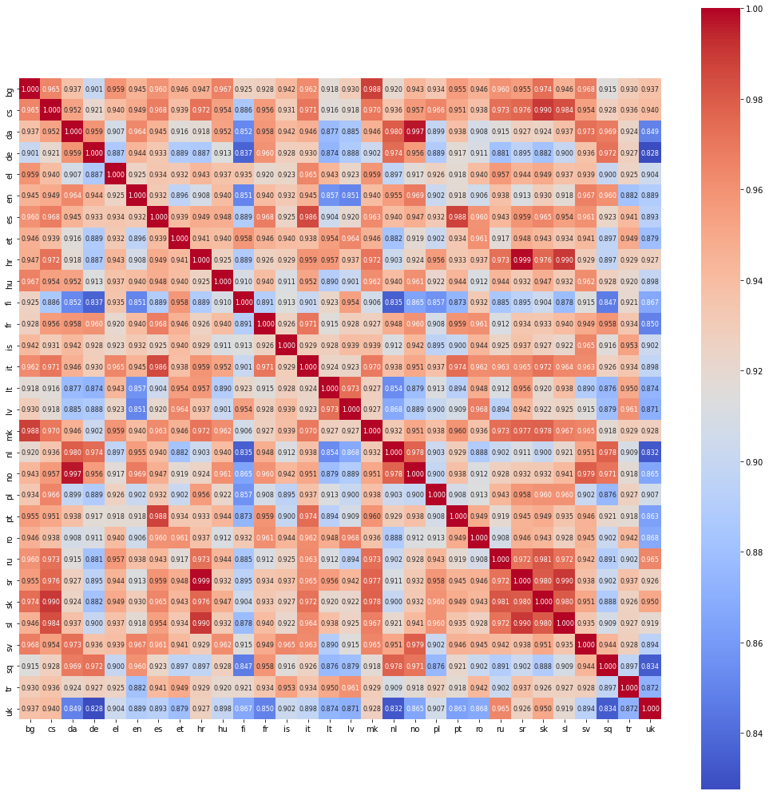

```python
plt.subplots(figsize=(18,18))
sns.heatmap(sim, cbar = True,  square = True,
            annot=True, fmt= '.3f',annot_kws={'size': 8},
            cmap= 'coolwarm')
```

Ovde vidimo da su jezici, naravno, najsličniji sami sebi. Zato imamo jedinice po dijagonali. Tamno crveno nam govori da su dva jezika vrlo slična, dok plavo znači da nemaju baš mnogo toga zajedničkog. Sami utvrdite koji su najsličniji.

Drugi način da podatke o jezicima grafički prikažemo jeste da nacrtamo dendrogram. Takav grafikon će prikazati kako se stablo grana, odnosno kako od nivoa sličnosti zavusi koliko grana jezika imamo.

```python
import scipy.cluster.hierarchy as sch
```

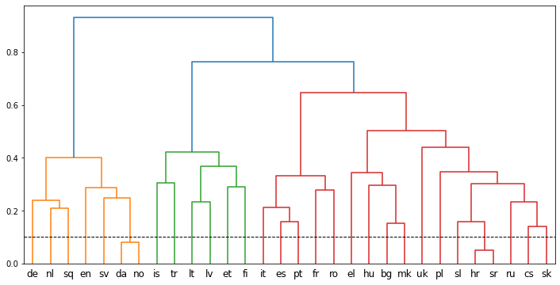

```python
# dendrogram
plt.subplots(figsize=(12,6))
d=dendrogram = sch.dendrogram(sch.linkage(df, method='ward'),leaf_rotation=0,labels=lista,leaf_font_size=12)
plt.axhline(y=.1, color='k', linestyle='--', lw=1)
```

## Završni komentar

Ova analiza ne pretenduje da zameni ili banalizuje lingvistčke analize. Ideja je bila samo da pokažemo jedan od načina kako jedna kompleksna pojava poput jezika može da se parametrizuje i da na osnovu toga vidimo šta je čemu slično. Način na koji bismo mogli da predstavimo npr. države, kompanije ili programe političkih stranaka ne bi bio mnogo drugačiji. Samo bismo izabrali nešto drugo sem frekvencije slova za parametre.